# Peaks analysis of ATAC-seq: BRG1-WT vs BRG1-KO

Preetida J Bhetariya

2022-04-07

```r
#if (!require("BiocManager", quietly = TRUE))
 #   install.packages("BiocManager")

#BiocManager::install("TxDb.Hsapiens.UCSC.hg38.knownGene")

loadlibs <- function(){
library(reshape)
library(pheatmap)
library(RColorBrewer)
library(DT)
library(ggrepel)
library(viridis)
library(Repitools)
library(knitr)
library(DESeq2)
library(DiffBind)
library(ChIPpeakAnno)
library(ChIPseeker)
library(ensembldb)
library(EnsDb.Hsapiens.v86)
library(AnnotationHub)
library(rtracklayer)
library(TxDb.Hsapiens.UCSC.hg19.knownGene)
library(tidyverse)
library(ChIPseeker)
}
suppressPackageStartupMessages(loadlibs())

knitr::opts_chunk$set(
    cache = FALSE,
    dev = c("png", "pdf"),
    error = TRUE,
    highlight = TRUE,
    message = FALSE,
    prompt = FALSE,
    tidy = FALSE,
    warning = FALSE,
    fig.align = 'center')
#getwd()
if (file.exists("./_setup.R")){
source("_setup.R")
}
# Set seed for reproducibility
set.seed(1454944673L)
```

```r
viridis_col <- viridis_pal()(20)
```

# 1 Overview

- **Principal Investigator:** Carla Kim
- **Researcher:** Marghe
- **Experiment:** BRG1 gene was knocked out in three celllines. The ATACseq experiemnt was performed on Brg1 KO and Brg1 WT This experiment analyzed ATACseq in three cells line where *BRG1* was knocked out.
- **Experimental details:**
- **Technical details:**
  - 6 - samples
  - ATACseq
  - No replicates

## 1.1 Setup data and metadata

First, we need to load the consensus count matrix and the associated metadata.

```r
## Load sample data
samples <- read.csv('../meta/Brg1_metadatasheet_NF.csv')
#head(samples)
```

```r
sanitize_datatable(samples, style='bootstrap')
```

|  | SampleID | samplename | Cellline | Replicate | bamReads | Peaks | PeakCaller | Treatment | Phenotype |
| --- | --- | --- | --- | --- | --- | --- | --- | --- | --- |
| 1 | S7 | S7_H460_WT-NF | H460 | 1 | /Users/prb102/Documents/BRG1_ATACseq/data/Bams/NFs/S7_H460_WT-NF.bam | /Users/prb102/Documents/BRG1_ATACseq/data/peakcalls/S7_H460_WT-NF_peaks.narrowPeak | narrow | BRG1-WT | WT |
| 2 | S8 | S8_H460_KO-NF | H460 | 1 | /Users/prb102/Documents/BRG1_ATACseq/data/Bams/NFs/S8_H460_KO-NF.bam | /Users/prb102/Documents/BRG1_ATACseq/data/peakcalls/S8_H460_KO-NF_peaks.narrowPeak | narrow | BRG1-NULL | KO |
| 3 | S9 | S9_H2009_WT-NF | H2009 | 1 | /Users/prb102/Documents/BRG1_ATACseq/data/Bams/NFs/S9_H2009_WT-NF.bam | /Users/prb102/Documents/BRG1_ATACseq/data/peakcalls/S9_H2009_WT-NF_peaks.narrowPeak | narrow | BRG1-WT | WT |
| 4 | S10 | S10_H2009_KO-NF | H2009 | 1 | /Users/prb102/Documents/BRG1_ATACseq/data/Bams/NFs/S10_H2009_KO-NF.bam | /Users/prb102/Documents/BRG1_ATACseq/data/peakcalls/S10_H2009_KO-NF_peaks.narrowPeak | narrow | BRG1-NULL | KO |
| 5 | S11 | S11_Calu6_WT-NF | Calu6 | 1 | /Users/prb102/Documents/BRG1_ATACseq/data/Bams/NFs/S11_Calu6_WT-NF.bam | /Users/prb102/Documents/BRG1_ATACseq/data/peakcalls/S11_Calu6_WT-NF_peaks.narrowPeak | narrow | BRG1-WT | WT |
| 6 | S12 | S12_Calu6_KO-NF | Calu6 | 1 | /Users/prb102/Documents/BRG1_ATACseq/data/Bams/NFs/S12_Calu6_KO-NF.bam | /Users/prb102/Documents/BRG1_ATACseq/data/peakcalls/S12_Calu6_KO-NF_peaks.narrowPeak | narrow | BRG1-NULL | KO |

## 1.2 NF Peaks analysis

### 1.2.1 sample concordance

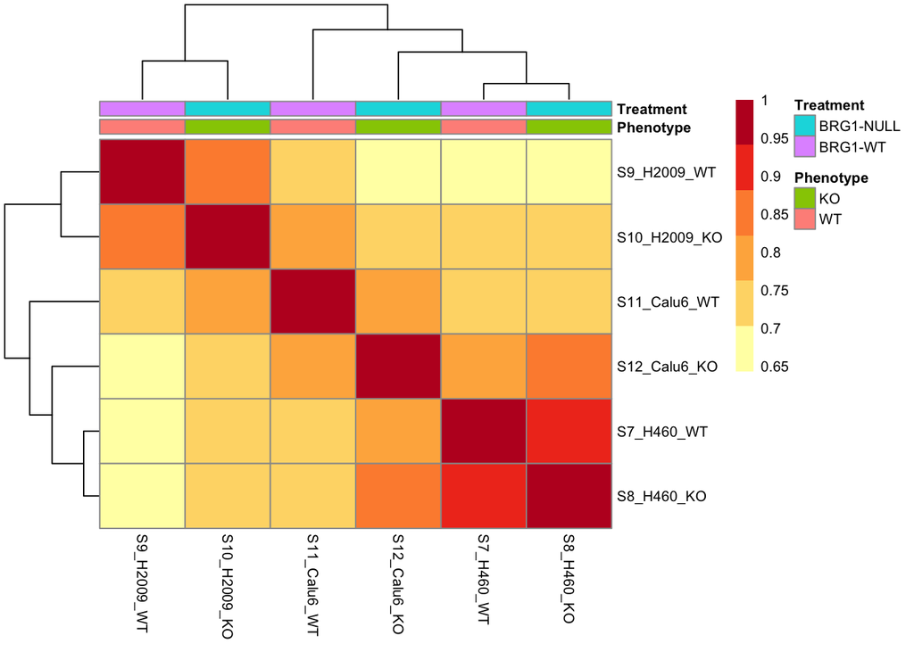

```r
# Load metadata
meta <- read.csv("../meta/Brg1_metadatasheet_NF_2.csv")

# Read in data
counts <- read.delim("../meta/multiBAMsummary.tab", sep="\t")

# Remove genomic coordinate information
plot_counts <- data.frame(counts[, 4:ncol(counts)])


# Change column names
colnames(plot_counts) <- colnames(plot_counts) %>%
  str_replace( "X.", "") %>%
  str_replace(".NF.", "")

#all(meta$shortname %in% colnames(plot_counts))
plot_counts <- plot_counts[ ,meta$sample]


annotation <- as.data.frame(meta[,c("Phenotype", "Treatment")])

#all(meta$sample == colnames(plot_counts))

rownames(annotation) <- meta$sample
heat.colors <- brewer.pal(6, "YlOrRd")

pheatmap(cor(plot_counts), color=heat.colors, annotation=annotation, fontsize = 8)
```

```r
cat('\n\n')
```

Here, we generate two plots to evaluate the concordance across three cell-lines; WT and KO phenotype.

- **Peak rank versus Peak enrichment:** In this plot, we are looking at each individual sample to evaluate what number of peaks we would retain if thresholding by peak enrichment. It is also valuable to see how this differs between three celllines.
- **Overlapping peaks:** The Venn diagram gives us a representation of the number of peaks overlapping between the three celllines. If there is a minimum of 1bp overlap between regions, then it is counted for one overlap. If multiple peaks are overlapping between two samples, connectedPeaks = “merge” will only add 1 to the overlapping counts.